# Progress Check 2

## Clarifications on question wording

## Models and Inference

- You want to use data to answer questions.
- Make *inferences* using *models* with data.

The method you use for inference is part of the model.

- Different sets of assumptions
- Many will give very similar answers

## Frameworks for Inference

1. Analytical
2. Maximum likelihood
3. Resampling (Monte Carlo)
4. Bayesian

Each is a tool with different costs and benefits.

## Confidence intervals

- Review CI simulation & exact CIs

## Understanding `lm()` output

[figure not shown]

## Understanding `lm()` output

[figure not shown]

## Understanding `lm()` output

[figure not shown]

## What makes a good predictor?

## Problem set 8

## Hierarchy of GLMs

[figure not shown]

## GLMs with 1 normally distributed outcome variable

### a.k.a., “General Linear Models”

1. Continuous ~ \(\ge\) 1 Continuous: **OLS, correlation (Pearson r), multiple correlation (R)**
2. Continuous ~ \(\ge\) 1 Categorical: **ANOVA, *t*-test**
3. Continuous ~ 1 Continuous + 1 Categorical: **ANCOVA**
4. Continuous ~ \(\ge\) 1 Continuous + \(\ge\) 1 Categorical: **Multiple regression**

## `anova()` vs. `lm()` vs. `aov()`

- Do we even need `t.test()`?

## Assumptions of linear models

- IID
- Normality of residuals
- Equality of variances

## What makes a model “linear”? When is a model non-linear?

Linear models:

- Response modeled by a combination of predictors where predictors are not in the exponents

\[y = \beta_ + \beta_1 x_1 + \beta_2 x_2 + ... + \beta_k x_k\]

- Interactions models (unit 9)

\[y = \beta_0 + \beta_1 x_1 + \beta_2 x_2 + \beta_3 x_1 x_2 + ... + \beta_k x_k\]

## Curved “linear” models? Yes.

\[y = \beta_0 + \beta_1 x^2\]

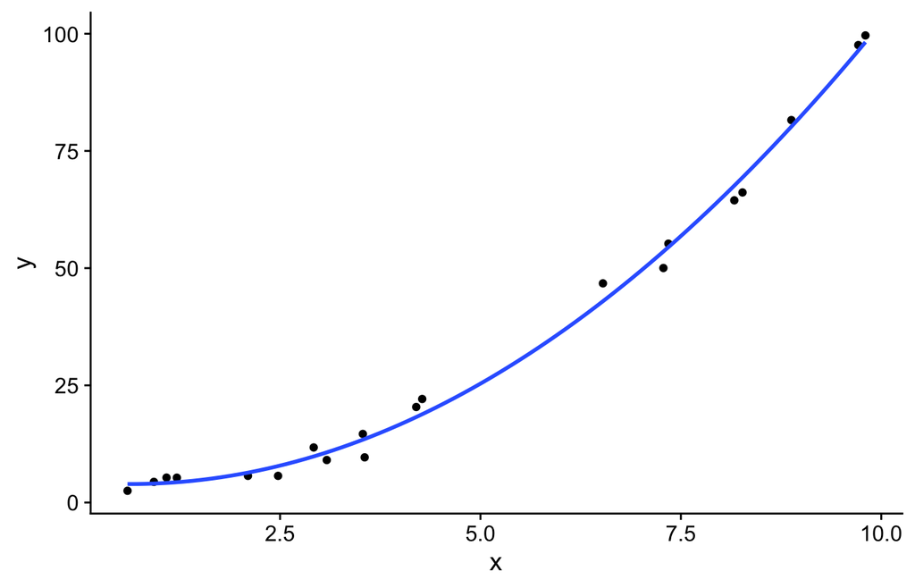

## Transformations

All are linear models:

- Least squares regression
- *t*-tests, ANOVA, etc.
- Polynomials
- Roots
- Logarithms
- Generalized linear models (logistic, Poisson regression)

## Non-linear models

- Models that are not “linear models”
- Usually:
  - Predictors in the exponents
  - Asymptotic

Logistic growth:

\[f(x) = \frac{\beta_{max}}{1 + e^{-\beta_{rate}(x - \beta_{mid})}}\]

Michaelis−Menten:

\[f(x) = \frac{ax}{b+x}\]

## Gompertz Growth Curve

\[f(t)=a\mathrm{e}^{-b\mathrm{e}^{-ct}}\]

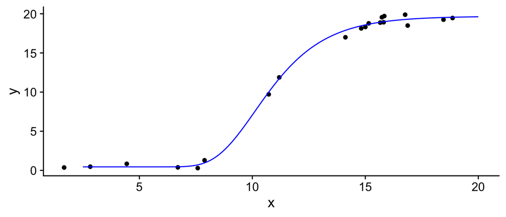

- No analytical solution (can’t use `lm()`)
- Need to use maximum likelihood or Bayesian inference
- Can be very challenging to fit (starting values)

## Programming

Lists, data.frames, and tibbles, and tables in loops

- Loops
- Functions
- Debugging code
- Map functions

Approaches:

- Start small, build up
- Stepwise additions, one change at a time
- Sanity check every step

## What is the expected distribution of P-values when there is no effect?

- Simulate data with no difference
- Extract P-value from summary
- Repeat many times
- Plot

## Publication ready figures

What you have been learning:

- `ggplot()`
- Theming: color, point and line size, text size, etc.
- Combining plots
  - `cowplot` package: `plot_grid()`
  - `patchwork` package: https://patchwork.data-imaginist.com/
- [ggpubr](http://www.sthda.com/english/articles/24-ggpubr-publication-ready-plots/)
- [Big list of ggplot extensions](https://github.com/erikgahner/awesome-ggplot2)